# Financial Data Exploratory Analysis

Esteban Sánchez

18 de febrero de 2019

The main of this .rmd is to show the data in the db_bsm_financial.csv and study different features from the varaibles. First of all we need to use the following packages, so let’s to call they.

```r
library(tidyverse)
library(lubridate)
library(ggplot2)
library(cowplot)
```

The database has 148 different columns which many of them is not going to be used so let’s to create shorter dataframes to achieve the goal of this .rmd

```r
fin_data <- read_csv('../data/db_bsm_financial.csv')
fin_data$date <- as.Date(fin_data$date, format = '%Y-%m-%d')

fin_data_plot <- fin_data %>% group_by(ticker) %>% arrange(date, .by_group = TRUE) %>%
  mutate(daily_pl = close - lag(close, default = first(close)), vol_mill = volume / 1000000) %>%
  select(ticker, date, close, daily_pl, volume, vol_mill) %>% arrange(ticker, desc(date)) %>% mutate(year = year(date))

fin_data_tech <- fin_data %>% group_by(ticker) %>% arrange(date, .by_group = TRUE) %>%
  mutate(daily_pl = close - lag(close, default = first(close))) %>%
  select(ticker, date, close, `SMA 14`, `SMA 21`, `SMA 42`) %>% arrange(ticker, desc(date)) %>% mutate(year = year(date), quarter = quarter(date))

fin_data_tech_trend <- fin_data %>% group_by(ticker) %>% arrange(date, .by_group = TRUE) %>% select(ticker, date, close, `ADX 14`, `ADX 21`, `ADX 42`, `MINUS_DI 14`, `MINUS_DI 21`,  `MINUS_DI 42`, `PLUS_DI 14`, `PLUS_DI 21`, `PLUS_DI 42`) %>% mutate(quarter = quarter(date), year = year(date)) %>% arrange(ticker, desc(date))
```

The following plot shows how is distributed the increase or decrease from yesterday to today over the four latest years for different companies.

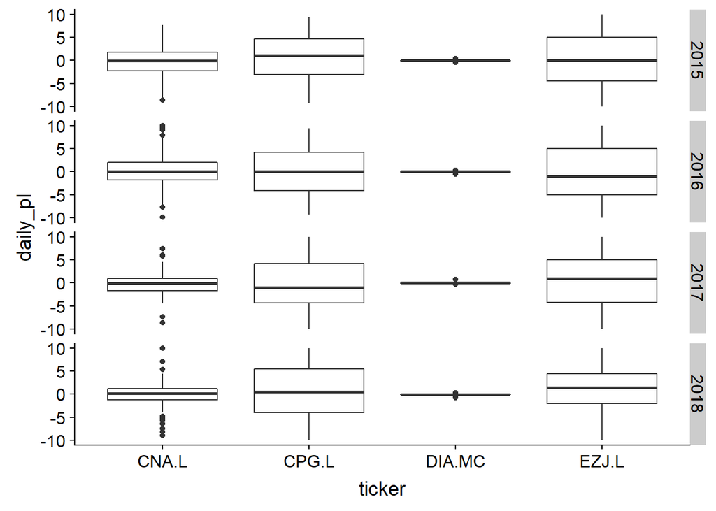

```r
fin_data_plot %>% filter(year > 2014 & year < 2019) %>%
  ggplot(aes(x = ticker, y = daily_pl)) + geom_boxplot() + ylim(-10,10) + facet_grid(year~.)
```

In this case the plots shows the same month by month for year 2017.

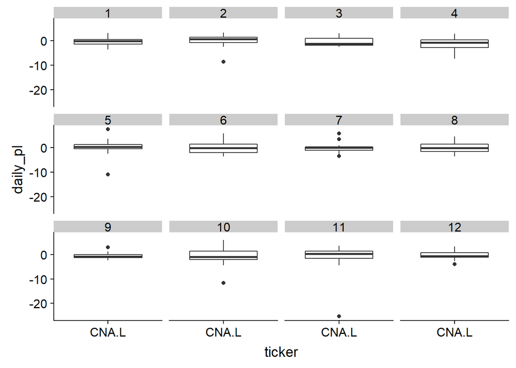

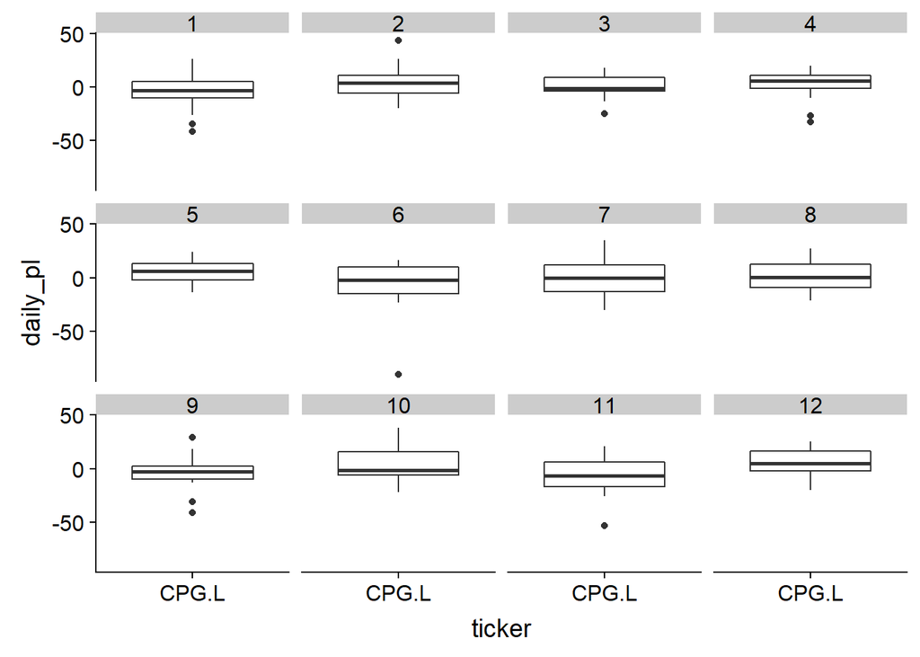

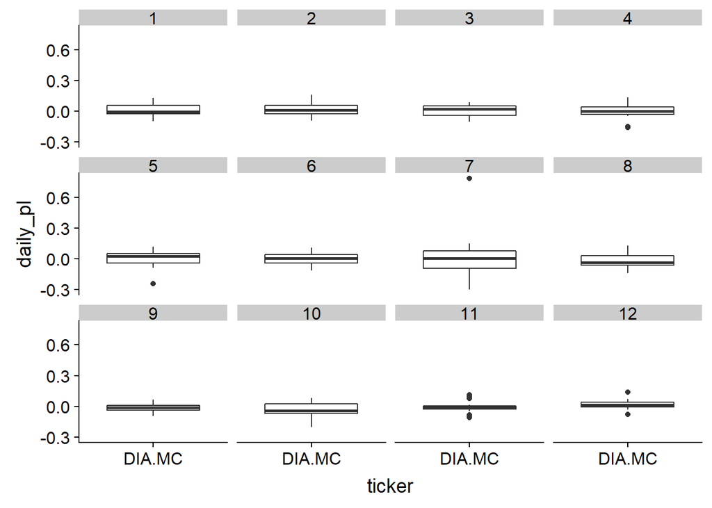

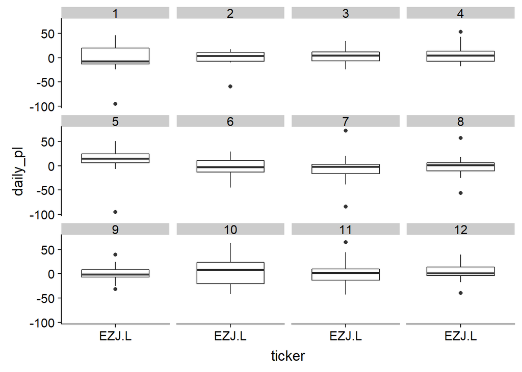

```r
for (tick in unique(fin_data_plot$ticker)){
  fig <- fin_data_plot %>% filter(year == 2017 & ticker == tick) %>% mutate(month = month(date)) %>%
  ggplot(aes(x = ticker, y = daily_pl)) + geom_boxplot() + facet_wrap(month~., ncol = 4)
  plot(fig)
}
```

Next plots show the close daily price, the volume (in millions, under the first chart), the increase or decresase from today to yesterday (daily_pl) where green is for an increase and red for the opposite and the orange area is the area where the price fluctuates in a normally way, understanding normally as the daily_pl between 25% percentile and 75% percentile of the year.

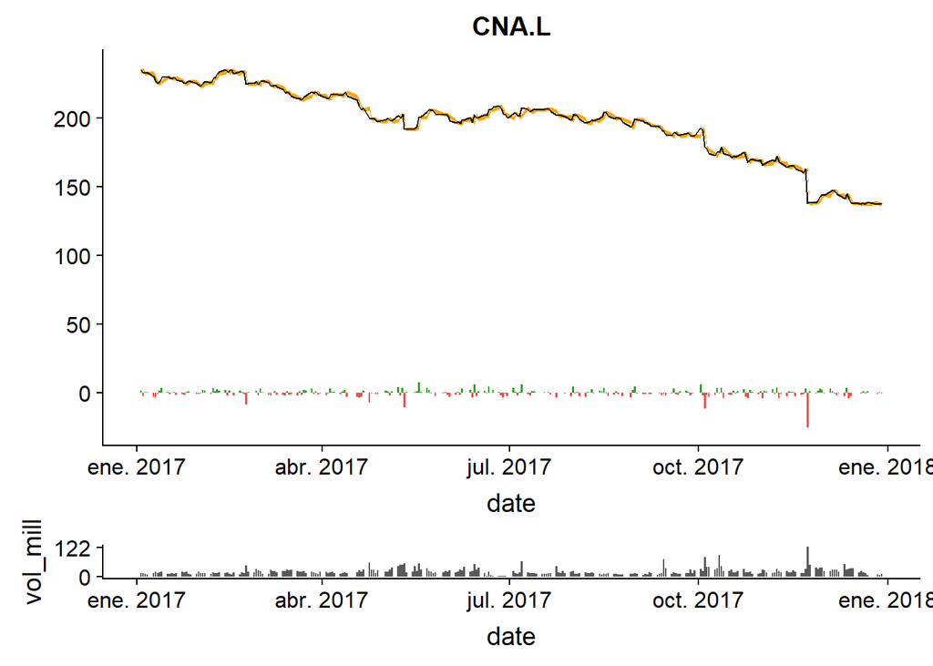

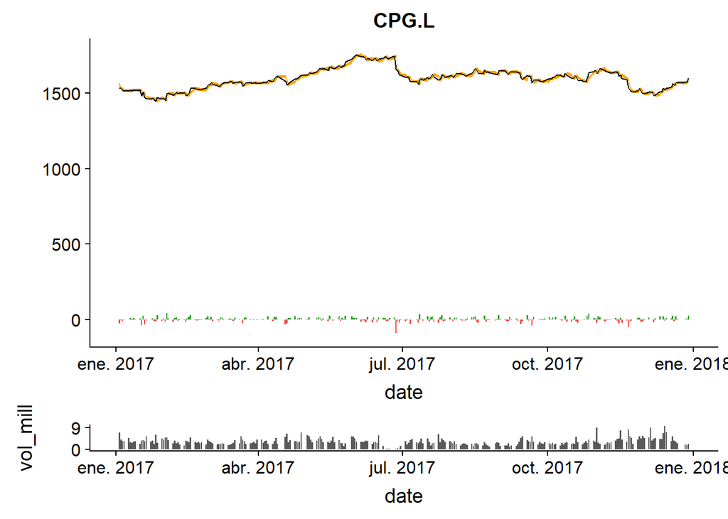

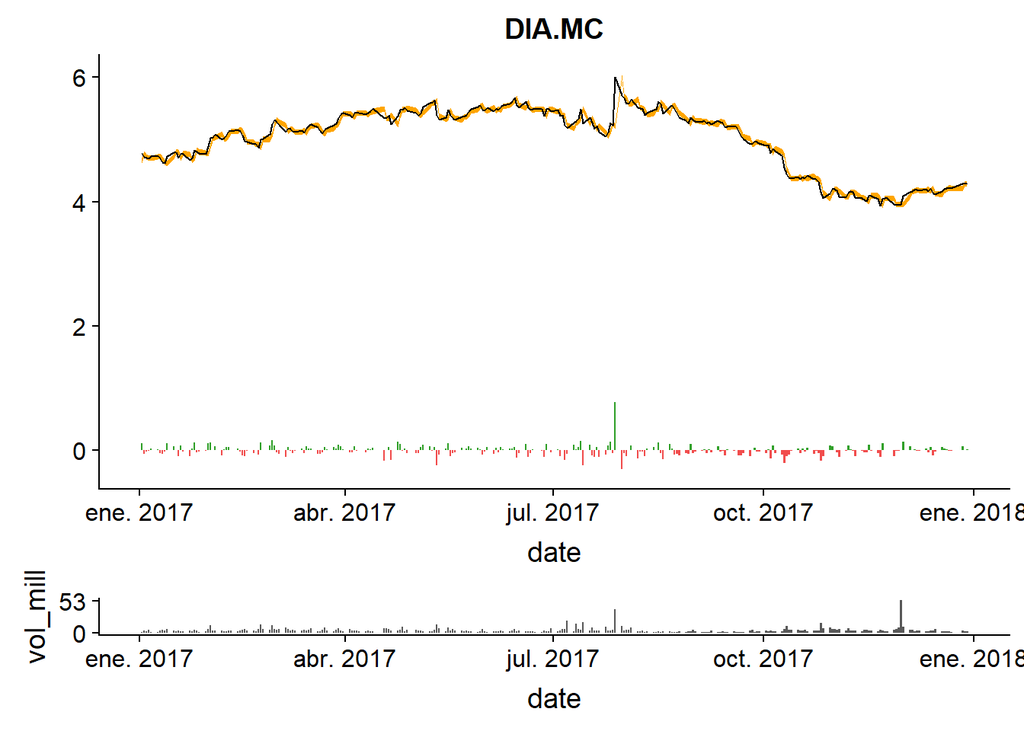

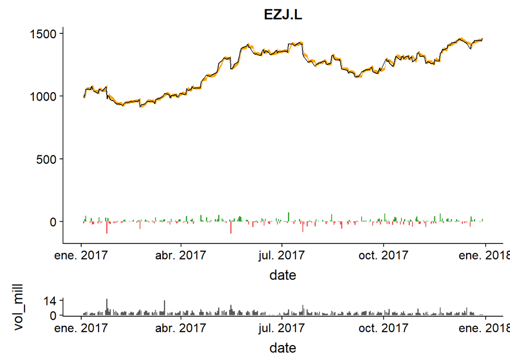

```r
for (tick in unique(fin_data_plot$ticker)){
  plot1 <- fin_data_plot %>% filter(year == 2017, ticker == tick) %>%
  mutate(colour = ifelse(daily_pl < 0, '#F14D4D', '#31A02A'),
         quant25 = quantile(daily_pl, 0.25), quant75 = quantile(daily_pl, 0.75)) %>%
  ggplot(aes(x = date)) + geom_bar(aes(y = daily_pl, fill=colour), stat = 'identity') +
  geom_ribbon(aes(ymin = (close - daily_pl + quant25),
                  ymax = (close - daily_pl + quant75), fill = 'orange')) + geom_line(aes(y = close)) +
  scale_fill_identity() + ggtitle(tick) + theme(axis.title.y = element_blank())
  min <- 0
  max <- fin_data_plot %>% filter(year == 2017, ticker == tick) %>% sapply(max)
  plot2 <- fin_data_plot %>% filter(year == 2017, ticker == tick) %>% ggplot(aes(x = date, y = vol_mill)) +
  geom_bar(stat = 'identity') + scale_y_continuous(breaks = c(round(min), round(as.numeric(max[6])) - 1))
  fig <- plot_grid(plot1, plot2, align = 'v', nrow = 2, rel_heights = c(4/5, 1/5))
  plot(fig)
}
```

The succesive plots display the moving average of 14, 21 and 42 days with the close price quarter by quarter in year 2017. The moving average is plotted to show how is the trend over “x” days and to know how is the market today front the “x” days.

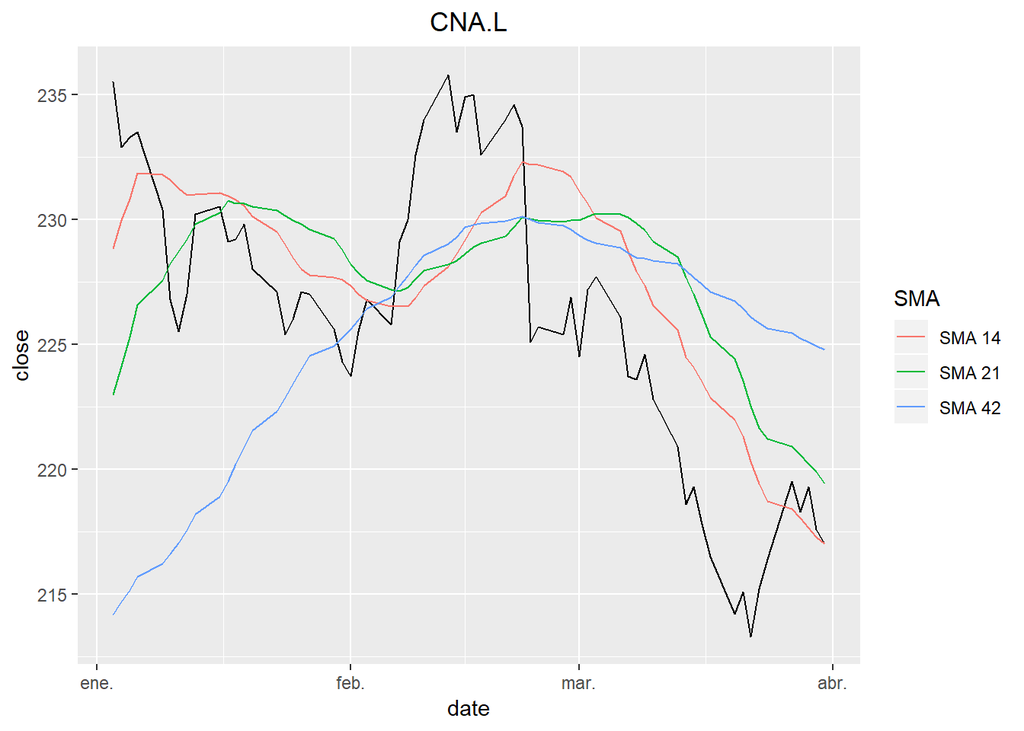

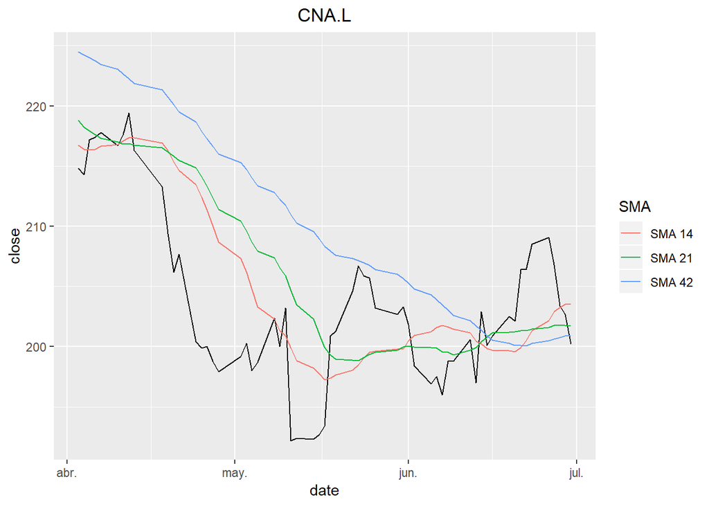

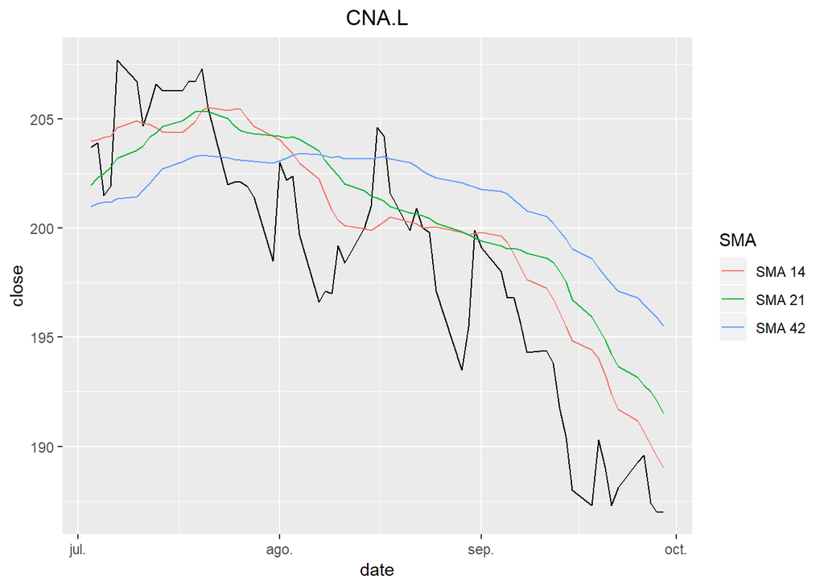

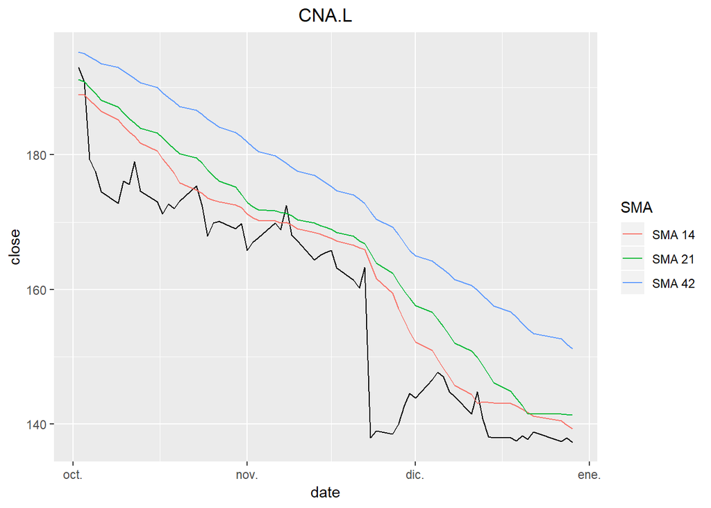

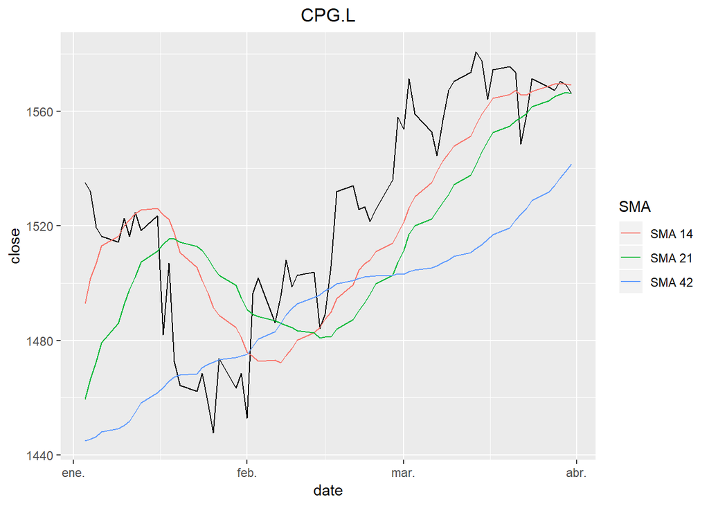

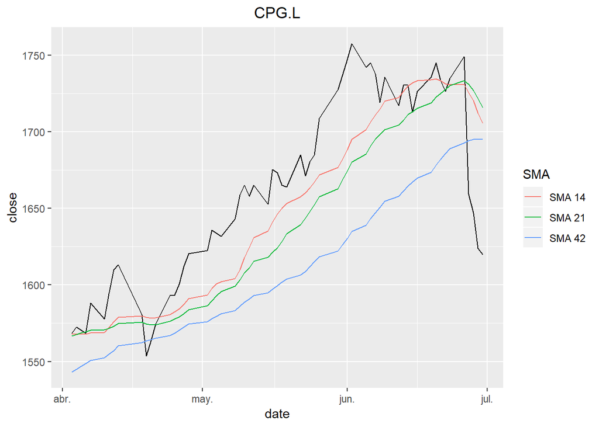

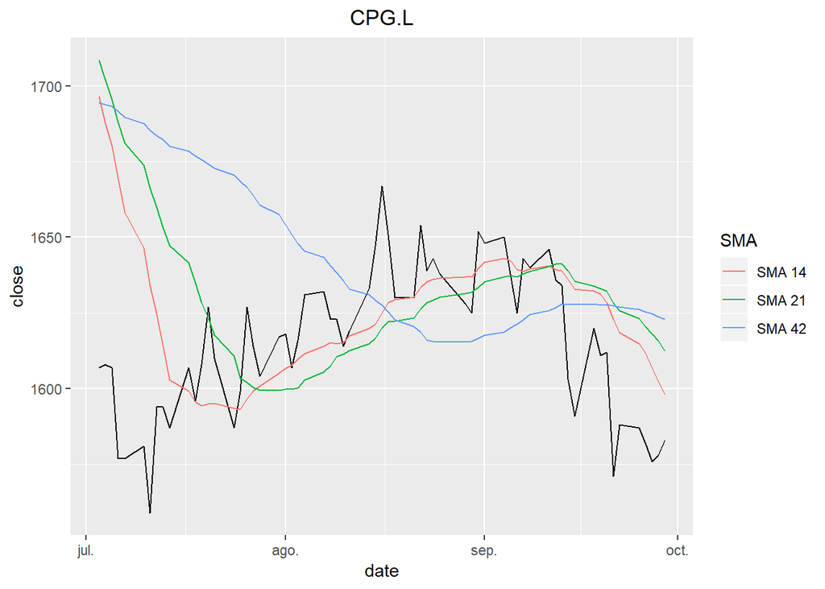

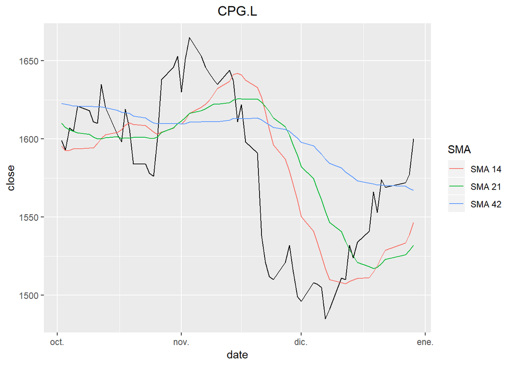

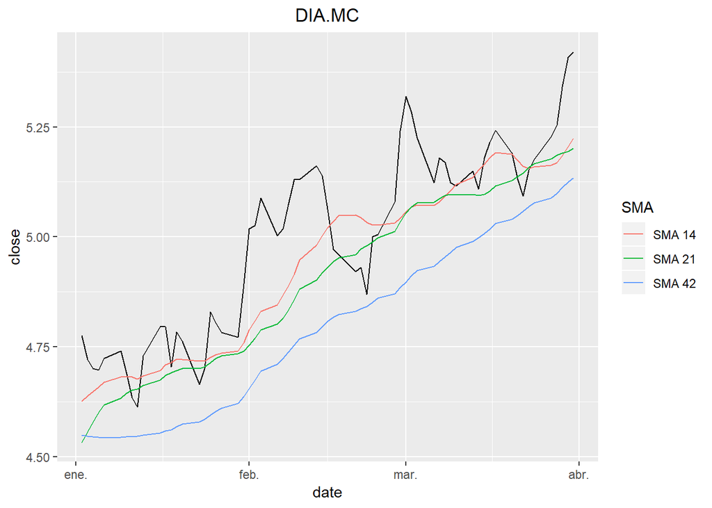

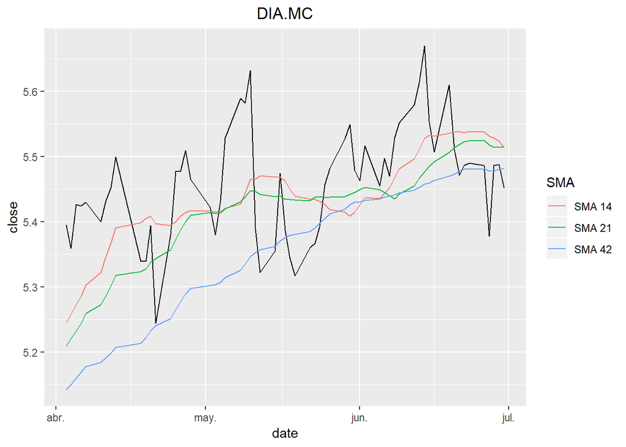

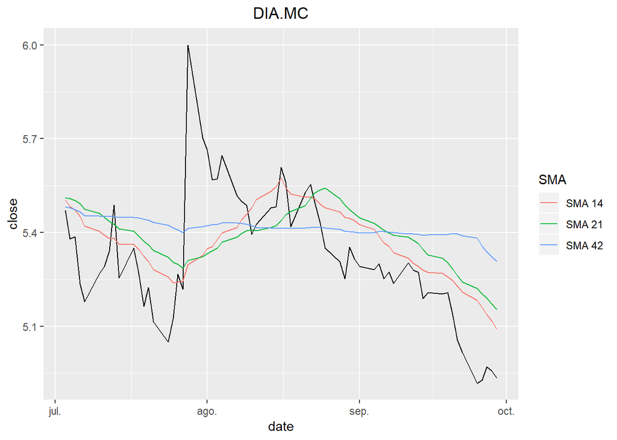

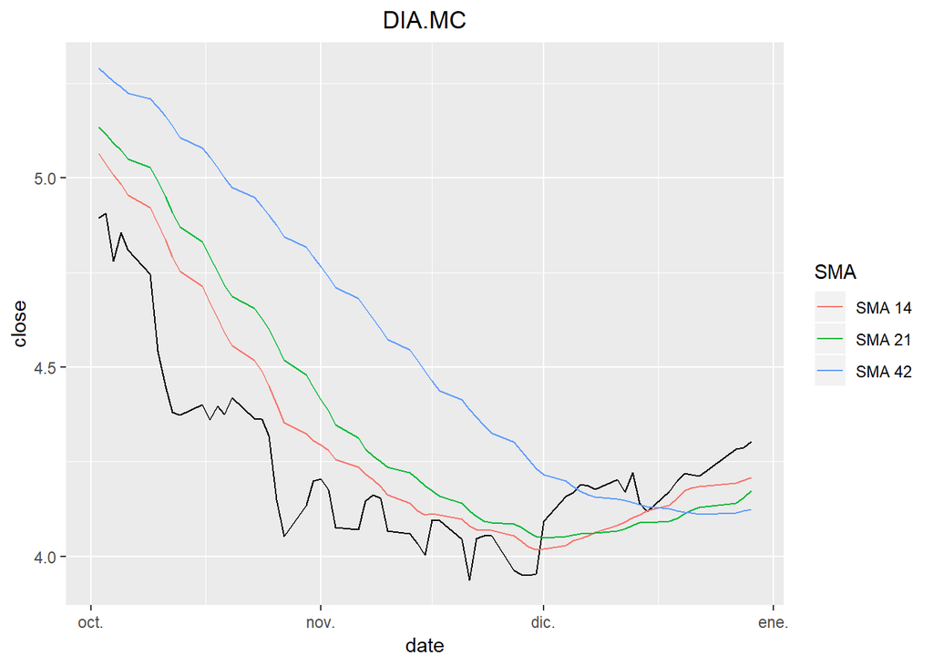

[4 more figures not shown]

```r
for (tick in unique(fin_data_tech$ticker)){
  for (qt in sort(unique(fin_data_tech$quarter))){
fig <- fin_data_tech %>% filter(year == 2017, quarter == qt, ticker == tick) %>%
  ggplot(aes(x=date)) + geom_line(aes(y = close)) +
  geom_line(aes(y = `SMA 14`, color='SMA 14')) +
  geom_line(aes(y = `SMA 21`, colour='SMA 21')) +
  geom_line(aes(y = `SMA 42`, color='SMA 42')) +
  scale_color_discrete(name='SMA', labels = waiver()) +
  theme_grey() + ggtitle(tick) +
  theme(plot.title = element_text(hjust = 0.5))
plot(fig)
  }
}
```

The latest plots show the strenght of a trend. ADX is for the strenght, plus_di and minus_di is for bull market and bear market respectivelly. If ADX is under 25 means no tendency so an higher value means tendency and an increase of volatility. Values higher to 40 is for strong tendencies.

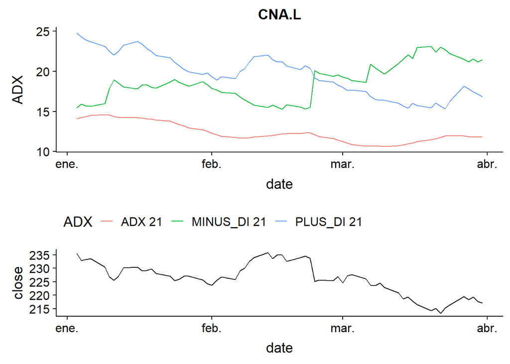

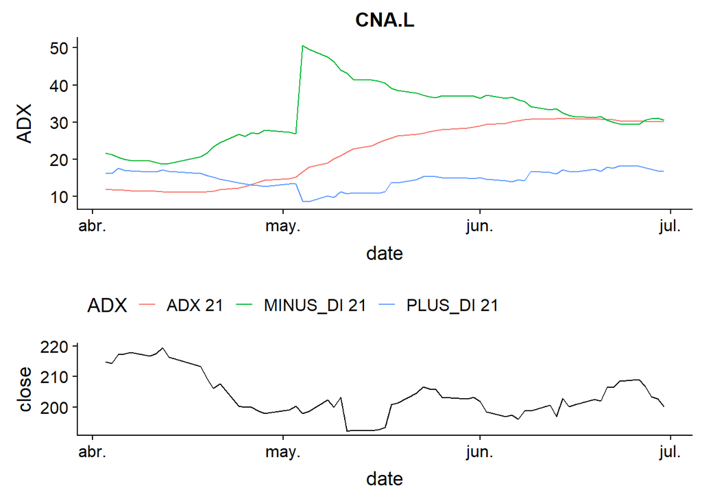

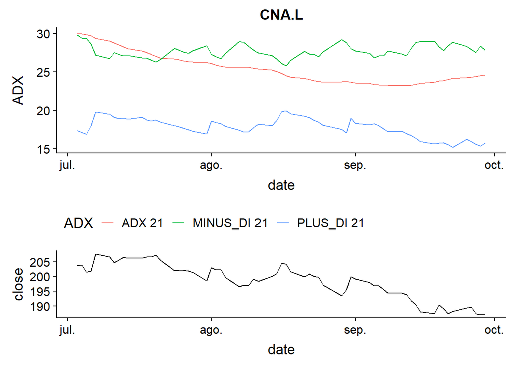

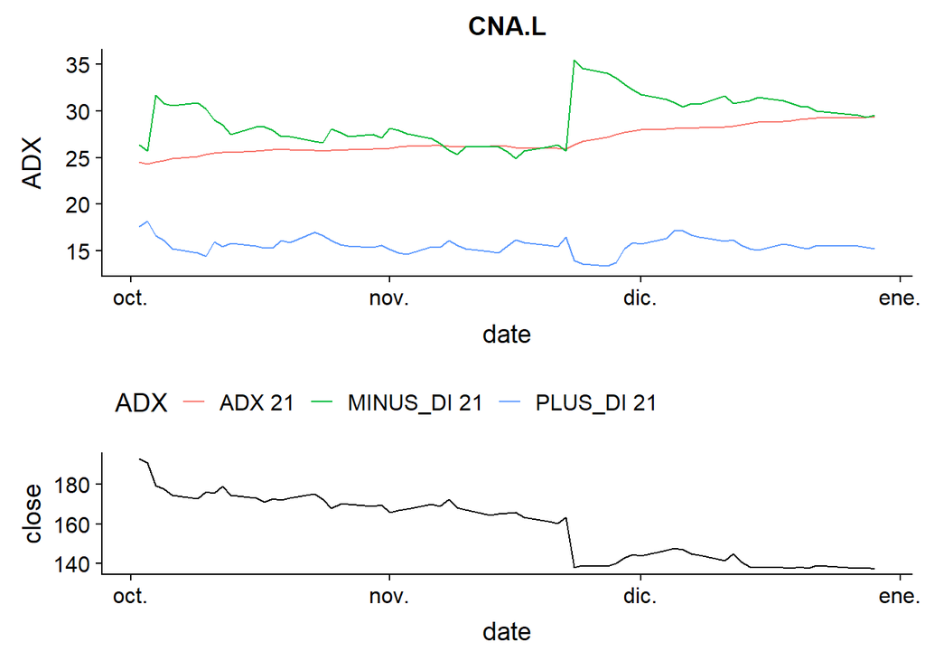

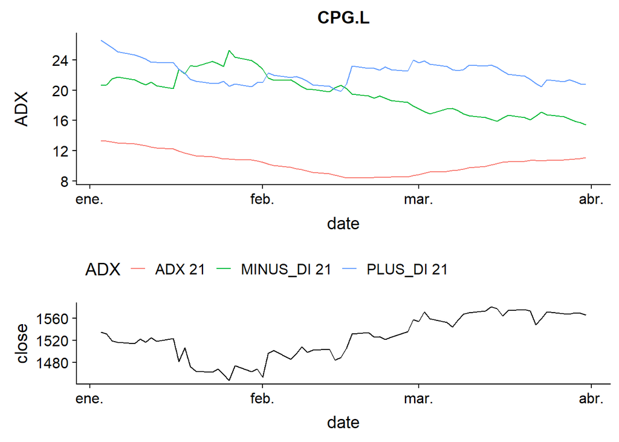

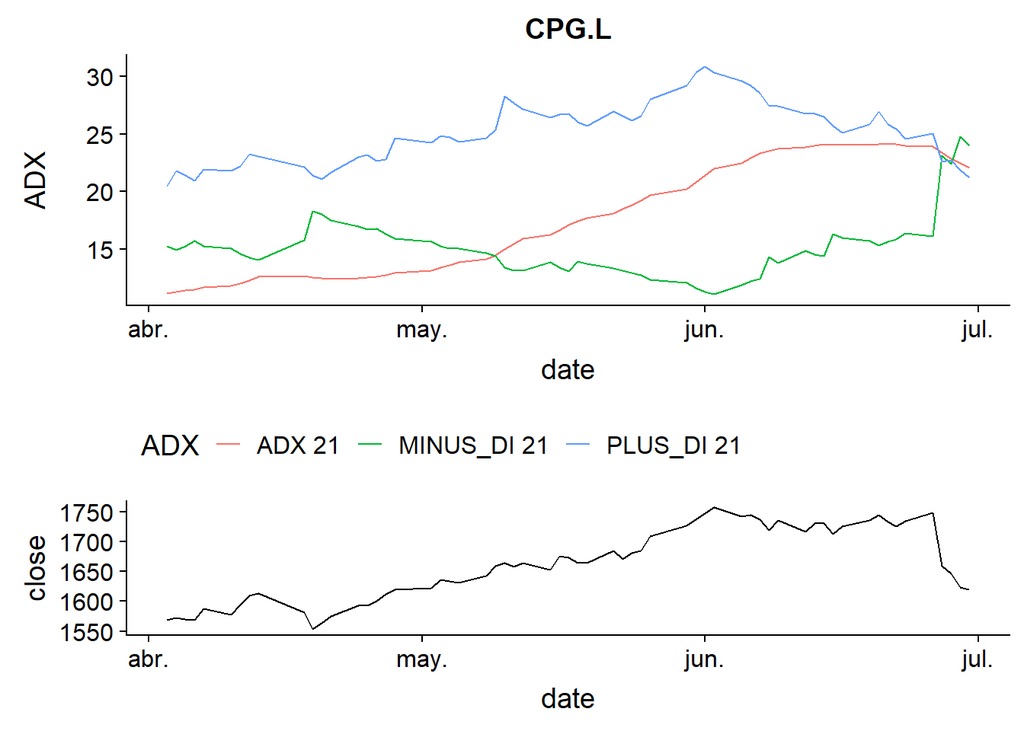

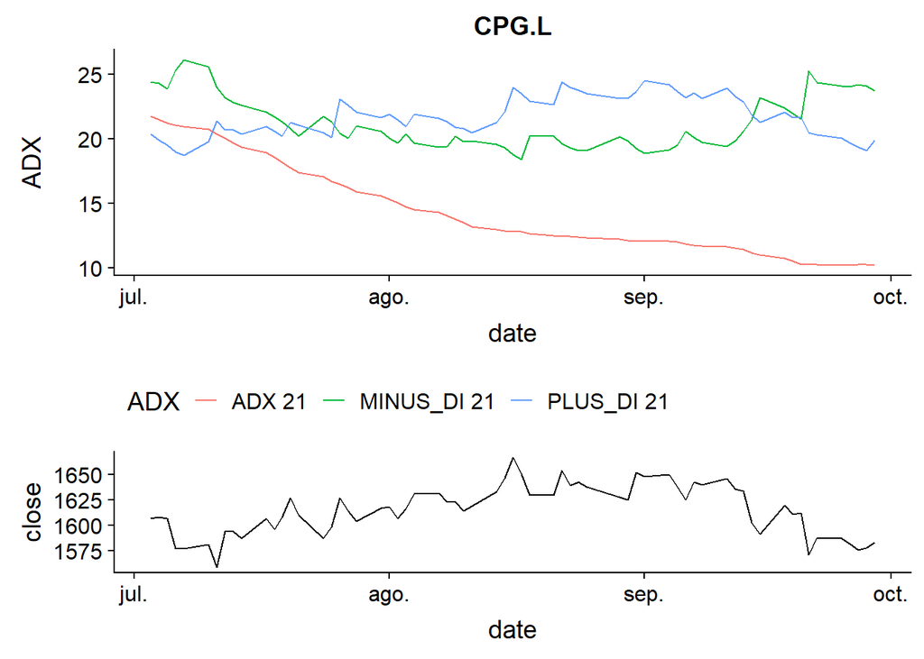

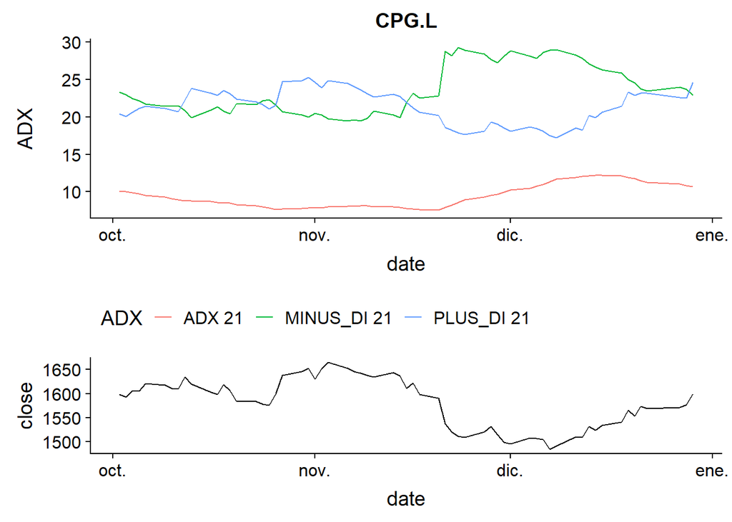

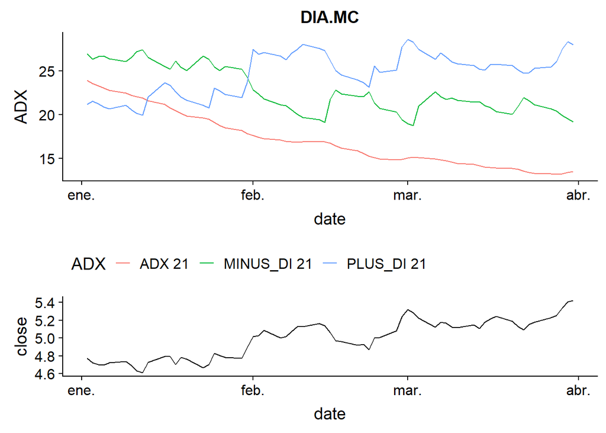

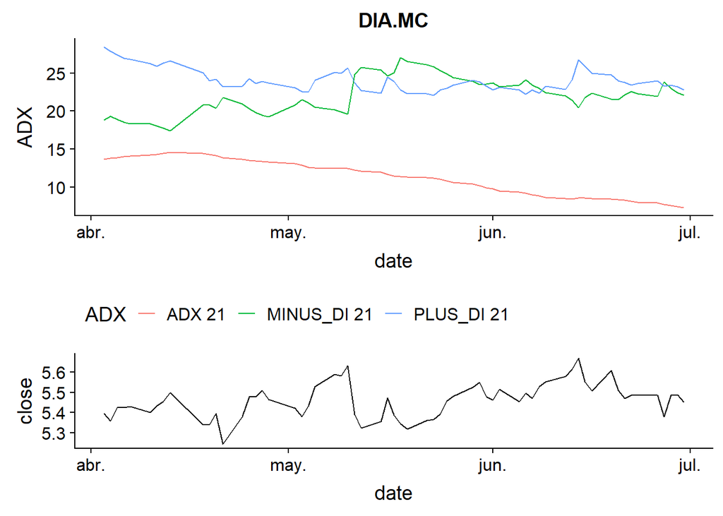

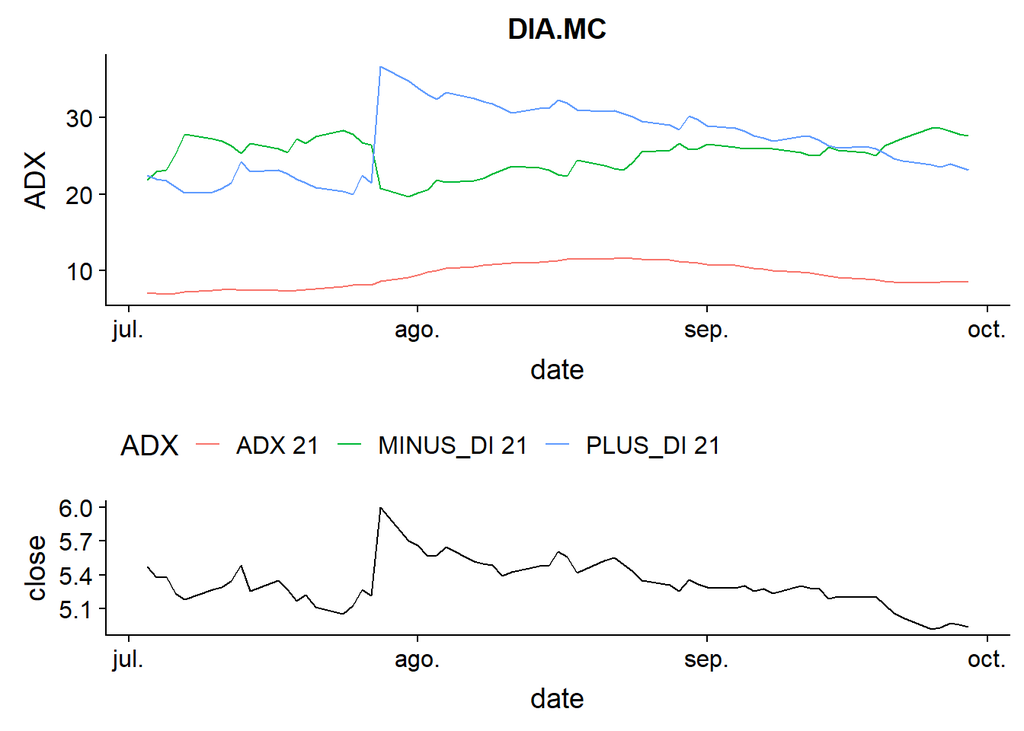

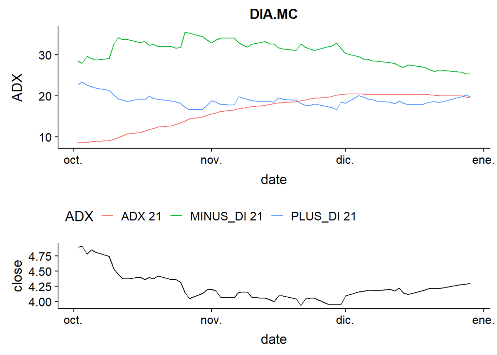

[4 more figures not shown]

```r
for (tick in unique(fin_data_tech_trend$ticker)){
  for (qt in sort(unique(fin_data_tech_trend$quarter))){

fig1 <-  fin_data_tech_trend %>% filter(ticker == tick, quarter == qt, year == 2017) %>%
  ggplot(aes(x = date)) +
  geom_line(aes(y = `ADX 42`, color = 'ADX 21')) +
  geom_line(aes(y = `MINUS_DI 42`, color = 'MINUS_DI 21')) +
  geom_line(aes(y = `PLUS_DI 42`, color='PLUS_DI 21')) +
  scale_color_discrete(name='ADX', labels = waiver()) +
  ggtitle(tick) + theme(legend.position = 'bottom') +
  labs(y = 'ADX')

  fig2 <- fin_data_tech_trend %>% filter(ticker == tick, quarter == qt, year == 2017) %>% ggplot(aes(x = date)) + geom_line(aes(y=close))


plot(plot_grid(fig1, fig2, align = 'v', nrow = 2, rel_heights = c(2/3, 1/3)))
}
}
```

In this .rmd only is studied two technical values that could “predict” how will be the value in the future. This is the idea of the project, to study which rules follow to minimize the failure with machine learning techniques.